1. Set any cells that are further that the provided maximum distance from the colony
2. Normalise to 0 and 1 probability of occurrence instead of distance
3. Multiple by colony size

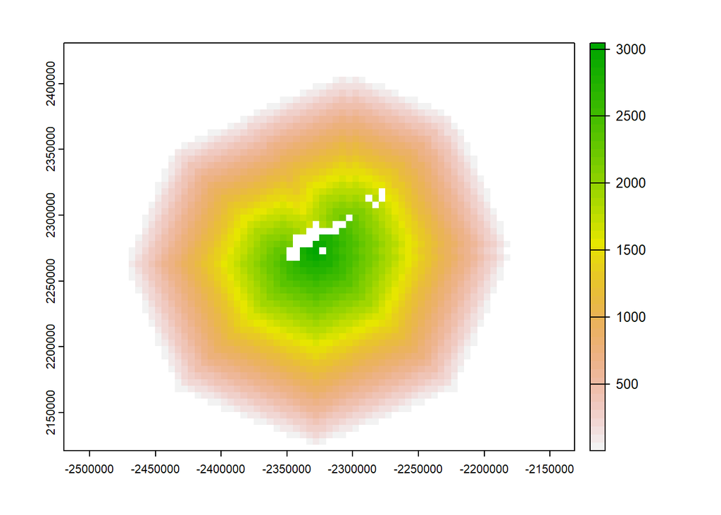

```r
## Set any cell further than maximum distance to NA
DistSea[DistSea > max_colony_radius] <- NA

## Normalise to 0 and 1 probability of occurrence (linear decay)
DistSea <- -1*(DistSea/max_colony_radius)+1

## Could can change to exponential or other decay function instead.
## [add options]

#Multiply by population size
PopRaster <- DistSea*colony_size

plot(PopRaster)
```

**Save raster outputs**

- Crop the raster to reduce file size and then save

```r
#create folders for maps to check results
outputs <- "/seaward_extension_outputs"
dir.create(outputs)

##Make buffer to crop raster
max_dist_buffer <- st_buffer(col_locs_proj, dist = max_colony_radius)

#crop to reduce size for saving
PopRaster <- terra::crop(PopRaster,
                       max_dist_buffer,
                       snap = "out")
#save
terra::writeRaster(PopRaster,paste0(wd,outputs,"/seaward-ext-single-col-dist.tif"), overwrite=T)
```

**Calculate IBA raster**

- Filter out cells containing less than 1% of the global population

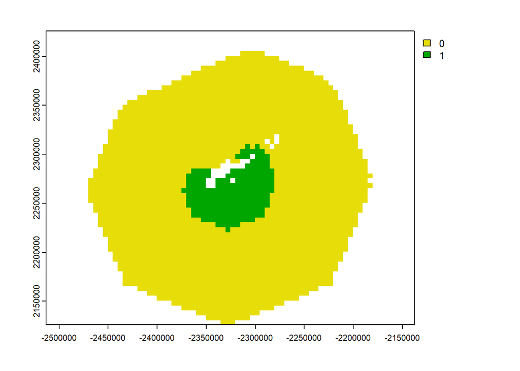

```r
#Convert to with more (1) or less (0) than 1% of global population
IBA_raster <- PopRaster
IBA_raster[IBA_raster < global_pop_size/100] <- 0
IBA_raster[IBA_raster >= global_pop_size/100] <- 1

#plot to check
plot(IBA_raster)
```

```r
#set to NA cells
IBA_raster[IBA_raster == 0] <- NA
```

**Calculate IBA polygon**

- Convert to polygon format
- Simplify the polygon to a more usable shape
- Cut out the area covered by land
- Save the output